# Kaggle-Expedia-Analysis

T.W Battaglia

09 May, 2018

### Data Import

Code below is presented only for reproducibility. The processed data is located within the R-object `training_processed.rda`. The command `load("training_processed.rda")` will load the object into the environment.

#### Import training data

```r
# Import using readr (faster)
training = read_csv('Data Mining VU data/training_set_VU_DM_2014.csv', na = "NULL")

# View column type summary
glimpse(training)
```

#### Expand the data_time feature

```r
# Expand the data-time into year, month, day, weekday
training = training %>%
  separate(date_time, c("ymd", "hour"), sep = " ", remove = F) %>%
  select(-hour) %>%
  mutate(ymd = ymd(ymd),
         wday = wday(date_time, label = TRUE),
         month = month(date_time, label = TRUE),
         week = week(date_time),
         day = day(date_time))
```

#### View column types

```r
# View column types summary after column changes
glimpse(training)
```

#### Save table as r-object for faster import

```r
# Save files as .rda objects
save(training, file = "training_processed.rda")
```

### Get Summary Statistics

#### Basic dimensions

```r
# View dimensions
dim(training)
```

```
## [1] 4958347      59
```

#### Number of unique searchs

Large amount of unique searchs to deal with.

```r
# Number of unique searches
training %>%
  group_by(srch_id) %>%
  tally() %>%
  nrow()
```

```
## [1] 199795
```

#### Range of the hotel prices

Very large range of hotel prices. Can be due to many different hotel-specific factors.

```r
# Number of unique searches
training %>%
  select(price_usd) %>%
  summary()
```

```
##    price_usd
##  Min.   :       0
##  1st Qu.:      85
##  Median :     122
##  Mean   :     254
##  3rd Qu.:     185
##  Max.   :19726328
```

#### Span of the bookings within the training data

Data does not include information over the entire year.

```r
# Differences between min and max days
max(training$ymd) - min(training$ymd)
```

```
## Time difference of 241 days
```

#### Distribution of length of stay

A majority of the searches have a short length of stay

```r
# Length of stay distribution
summary(training$srch_length_of_stay)
```

```
##    Min. 1st Qu.  Median    Mean 3rd Qu.    Max.
##   1.000   1.000   2.000   2.385   3.000  57.000
```

```r
# Length of stay distribution figure
training %>%
  group_by(srch_length_of_stay) %>%
  tally() %>%
  ungroup() %>%
  mutate(Percent = (n / sum(n)) * 100)
```

```
## # A tibble: 36 x 3
##    srch_length_of_stay       n Percent
##                  <int>   <int>   <dbl>
##  1                   1 2143980  43.2
##  2                   2 1203153  24.3
##  3                   3  717298  14.5
##  4                   4  373594   7.53
##  5                   5  185744   3.75
##  6                   6  102671   2.07
##  7                   7  117171   2.36
##  8                   8   33584   0.677
##  9                   9   19224   0.388
## 10                  10   16769   0.338
## # ... with 26 more rows
```

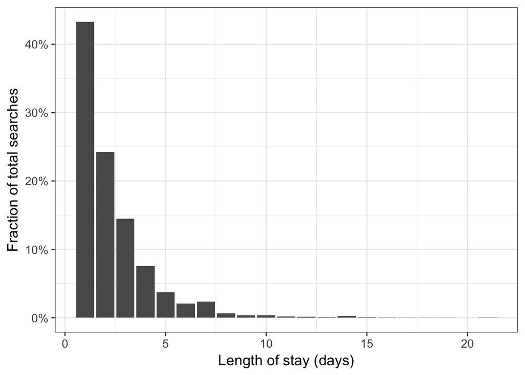

```r
# Length of stay distribution figure
training %>%
  group_by(srch_length_of_stay) %>%
  tally() %>%
  top_n(20) %>%
  arrange(desc(n)) %>%
  ggplot(aes(x = srch_length_of_stay, y = n / 4958347)) +
  geom_bar(stat = "identity") +
  theme_bw(base_size = 14) +
  scale_y_continuous(labels = scales::percent) +
  xlab("Length of stay (days)") +
  ylab("Fraction of total searches")
```

#### Number of clicks & bookings

Data set is very imbalanced with many more searches that were not clicked or not booked.

```r
# Number of clicks & bookings == TRUE
training %>%
  group_by(click_bool, booking_bool) %>%
  tally() %>%
  ungroup() %>%
  mutate(Percent = (n / sum(n)) * 100)
```

```
## # A tibble: 3 x 4
##   click_bool booking_bool       n Percent
##        <int>        <int>   <int>   <dbl>
## 1          0            0 4736468   95.5
## 2          1            0   83489    1.68
## 3          1            1  138390    2.79
```

```r
# Is there nay missing values for clicks?
skimr::skim(training$click_bool)
```

```
## Skim summary statistics
##
## Variable type: integer
##             variable missing complete       n  mean   sd p0 p25 p50 p75
##  training$click_bool       0  4958347 4958347 0.045 0.21  0   0   0   0
##  p100     hist
##     1 ▇▁▁▁▁▁▁▁
```

```r
# Is there nay missing values for bookings?
skimr::skim(training$booking_bool)
```

```
## Skim summary statistics
##
## Variable type: integer
##               variable missing complete       n  mean   sd p0 p25 p50 p75
##  training$booking_bool       0  4958347 4958347 0.028 0.16  0   0   0   0
##  p100     hist
##     1 ▇▁▁▁▁▁▁▁
```

#### Booking and Clicking instances

```r
# Find the srch_ids click/book rates
srch_id_none = training %>%
  group_by(srch_id) %>%
  summarise(Total_query = length(srch_id),
            Click_count = sum(click_bool),
            Book_count = sum(booking_bool)) %>%
  arrange(desc(Click_count))
```

#### Number of properties

There are a large amount of unique properties within the dataset, but a fairly equal representation of each property.

```r
# Number of properties
## 129,113 different properties
## Top property has 2357 searches
training %>%
  group_by(prop_id) %>%
  tally() %>%
  top_n(20) %>%
  arrange(desc(n))
```

```
## # A tibble: 20 x 2
##    prop_id     n
##    <fct>   <int>
##  1 104517   2357
##  2 124342   2355
##  3 68420    2285
##  4 40279    2275
##  5 134154   2257
##  6 137997   2247
##  7 59781    2245
##  8 60846    2237
##  9 49656    2230
## 10 77089    2230
## 11 59657    2190
## 12 35223    2189
## 13 116942   2189
## 14 38419    2177
## 15 60468    2175
## 16 21018    2170
## 17 24545    2169
## 18 14082    2152
## 19 77795    2150
## 20 37818    2139
```

#### Number of sites

There is a dominating website/search portal that has a large amount of the searches. I assume this is expedia.com.

```r
# Number of sites to book from
## 34 different sites
training %>%
  group_by(site_id) %>%
  tally() %>%
  top_n(20) %>%
  arrange(desc(n))
```

```
## # A tibble: 20 x 2
##    site_id       n
##    <fct>     <int>
##  1 5       3086006
##  2 14       481664
##  3 15       310788
##  4 24       237838
##  5 32       177330
##  6 18       127397
##  7 16        90032
##  8 12        73891
##  9 19        42758
## 10 9         42171
## 11 22        40262
## 12 11        34656
## 13 7         32067
## 14 29        29475
## 15 31        24420
## 16 26        16182
## 17 4         13499
## 18 25        12304
## 19 23        11620
## 20 1         10943
```

#### Number of destination countries

```r
# Number of destinations
## 172 different destinations
training %>%
  group_by(prop_country_id) %>%
  tally() %>%
  ungroup() %>%
  mutate(Percent = (n / sum(n)) * 100) %>%
  arrange(desc(Percent))
```

```
## # A tibble: 172 x 3
##    prop_country_id       n Percent
##    <fct>             <int>   <dbl>
##  1 219             3030125   61.1
##  2 100              311283    6.28
##  3 55               186465    3.76
##  4 31               154287    3.11
##  5 99               135388    2.73
##  6 129               91858    1.85
##  7 215               79981    1.61
##  8 220               71115    1.43
##  9 59                69453    1.40
## 10 216               61096    1.23
## # ... with 162 more rows
```

#### Number of destinations

There are some destinations that appear more frequently. This could be major cities, like NYC or Chicago.

```r
# Number of destinations
## 18,127 different destinations
training %>%
  group_by(srch_destination_id) %>%
  tally() %>%
  top_n(20) %>%
  arrange(desc(n))
```

```
## # A tibble: 20 x 2
##    srch_destination_id     n
##    <fct>               <int>
##  1 8192                69832
##  2 4562                57090
##  3 9402                40629
##  4 8347                33274
##  5 10979               33264
##  6 13292               32094
##  7 13870               29614
##  8 18774               27146
##  9 23904               26422
## 10 13216               23900
## 11 24700               23692
## 12 20319               23247
## 13 3073                22393
## 14 5143                22009
## 15 15307               21739
## 16 6948                20744
## 17 26067               19529
## 18 15122               19065
## 19 21871               18864
## 20 17713               17933
```

#### Origins + Destinations

Many of the origin and destinations are within the same country. I assume county code 219 is U.S.A.

```r
# Origin + Destination
training %>%
  group_by(visitor_location_country_id, prop_country_id) %>%
  tally() %>%
  ungroup() %>%
  top_n(20) %>%
  arrange(desc(n))
```

```
## # A tibble: 20 x 3
##    visitor_location_country_id prop_country_id       n
##    <fct>                       <fct>             <int>
##  1 219                         219             2520995
##  2 100                         100              229845
##  3 100                         219              178161
##  4 55                          55                95659
##  5 219                         100               56839
##  6 216                         219               50571
##  7 220                         220               48002
##  8 55                          219               43929
##  9 220                         219               41260
## 10 31                          31                39412
## 11 129                         129               37298
## 12 219                         31                33817
## 13 59                          59                29649
## 14 219                         59                27662
## 15 219                         55                26883
## 16 216                         216               26769
## 17 129                         219               25996
## 18 158                         158               24218
## 19 55                          99                23928
## 20 219                         99                23483
```

#### Number of missing values percentages

Many of the missing values come from the competitor values. This must be dealt with later.

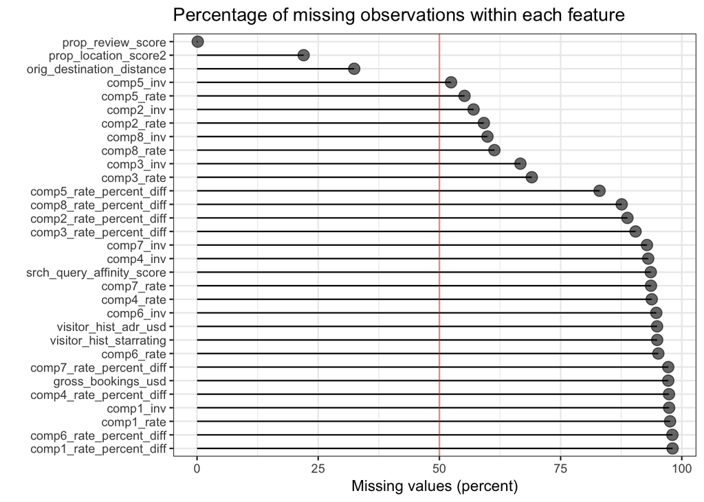

```r
# Gather the amount of missing values in each column
missing_values = training %>%
  summarise_all(funs(100 * mean(is.na(.) ))) %>%
  gather(Variable, Value) %>%
  arrange(desc(Value)) %>%
  mutate(Variable = as_factor(Variable))

# Write table to disk
write.csv(missing_values, "missing_values.csv")

# Simple dotplot of missing values percentages
missing_values %>%
  filter(Value > 0) %>%
  ggplot(aes(x = Variable, y = Value)) +
  geom_point(stat = 'identity', fill = "black", size = 3.5, alpha = 0.60) +
  geom_segment(aes(y = 0,
                   x = Variable,
                   yend = Value,
                   xend = Variable),
               color = "black") +
  coord_flip() +
  xlab("") + ylab("Missing values (percent)") +
  theme_bw() +
  geom_hline(yintercept = 50, color = "red", alpha = 0.45) +
  ggtitle("Percentage of missing observations within each feature")
```

### Properties of clicked hotels

#### Subset to view only clicked hotels

```r
# Subset to view only clicked hotels
training_click = training %>%
  filter(click_bool == 1)

# Get dimensions
dim(training_click)
```

```
## [1] 221879     59
```

### Properties of booked hotels

#### Subset to view only booked hotels

```r
# Subset to view only booked hotels
training_booked = training %>%
  filter(booking_bool == 1)

# Get dimensions
dim(training_booked)
```

```
## [1] 138390     59
```

#### View booking-rates over seasonality

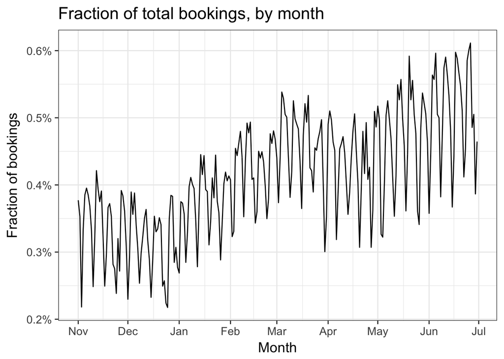

```r
# Count booked occurances per day
training_booked %>%
  group_by(ymd) %>%
  tally() %>%
  mutate(Fraction = n / 138390) %>%
  ggplot(aes(x = ymd, y = Fraction)) +
  geom_line() +
  theme_bw(base_size = 14) +
  scale_y_continuous(labels = scales::percent) +
  scale_x_date(date_breaks = "1 month", date_labels = "%b") +
  xlab("Month") +
  ylab("Fraction of bookings") +
  ggtitle("Fraction of total bookings, by month")
```

#### View booking-rates by week

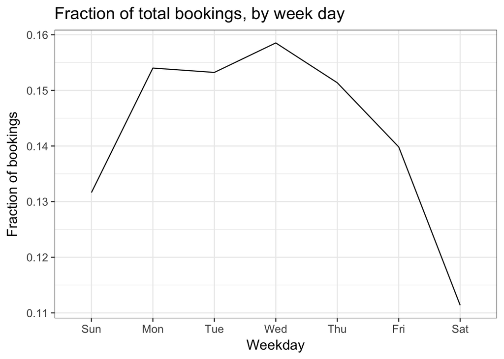

```r
# Count booked occurances per week
training_booked %>%
  group_by(wday) %>%
  tally() %>%
  mutate(Fraction = n / 138390) %>%
  ggplot(aes(x = wday, y = Fraction, group = 1)) +
  geom_line() +
  theme_bw(base_size = 14) +
  xlab("Weekday") +
  ylab("Fraction of bookings") +
  ggtitle("Fraction of total bookings, by week day")
```